# PSYC40940: Customising visualisations

## Before we start

1. Please complete the **Student Voice** section on NOW.
2. Complete last week’s exercises.
3. This is the last session on `ggplot2`. We will move one to shiny apps next week.

## General outline for weeks 2 – 5

- Week 2: Principles of data visualisation
- Week 3: Grammar of graphics; aesthetics and attributes
- Week 4: Major visualisation tools
- Week 5: Customising visualisations (scales, themes, and labels)

## Objectives for today

By the end of this session, you should be able to \(\dots\)

1. Customise `ggplot2` visualisations using scales, themes, and labels to enhance clarity and impact.
2. Apply design principles (e.g., Tufte’s guidelines) to reduce chartjunk and improve interpretability.
3. Tailor visualisations for different audiences and media, ensuring accessibility and effective communication.

Download exercises from Week 5 folder on NOW and move them into your R-project directory.

## Why customisation matters in data visualisation

1. **Visuals shape understanding**: a well-designed plot doesn’t just show data; it tells a story. Ensure that the story is clear, accurate, and compelling.
2. **Audiences vary**: tailor your visuals to the audience’s needs and expectations.
3. **Medium matters**: plots for journal articles, posters, or interactive dashboards each require different design choices.
4. **Avoiding misinterpretation**: poor design choices – like misleading axes or cluttered legends – can obscure key insights or even lead to incorrect conclusions.
5. **Accessibility and inclusivity**: thoughtful use of colour, labels, and themes can make your plots more accessible (e.g. people with visual impairments).

## Maximising clarity and minimising chartjunk through thoughtful design choices!

Revisiting Tufte’s Principles (Tufte, 2001):

- **Data-Ink ratio**: Maximise the proportion of ink that represents data.
- **Chartjunk**: Avoid unnecessary decoration (3D effects, heavy gridlines, etc.).
- **Small multiples**: Use consistent scales and layout to compare across categories.
- **Narrative graphics**: Use annotations and labels to guide interpretation.

## Applying Tufte to `ggplot2`

How does `ggplot2` supports Tufte’s principles:

- Minimal and custom themes to improve readability (`theme_minimal()`, `theme_void()`)
- Transform and resize scales to reduce distortion
- Direct labeling vs legends to make plots self-explanatory
- Faceting for small multiples (`facet_wrap()`, `facet_grid()`)
- Reduce overplotting: `position_dodge()`, `alpha = .5`, `size = .5`
- Inclusive colour schemes, grey scale, combining aesthetics

The grammar of graphics implemented in `ggplot2` by Hadley Wickham aligns with Tufte’s principles.

## Changing text: `labs`

- `title`
- `subtitle`
- `caption`
- `tag`
- `x`
- `y`
- `colour`, `shape`, `linetype`, `fill`

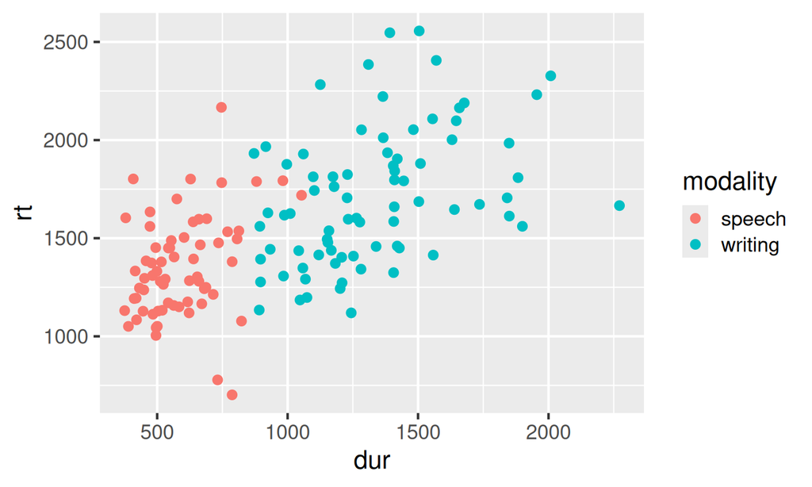

```r
ggplot(d_spellname, aes(y = rt, x = dur,
                          colour = modality)) +
  geom_point() +
  labs()
```

## Changing text: `labs`

- `title`
- `subtitle`
- `caption`
- `tag`
- `x`
- `y`
- `colour`, `shape`, `linetype`, `fill`

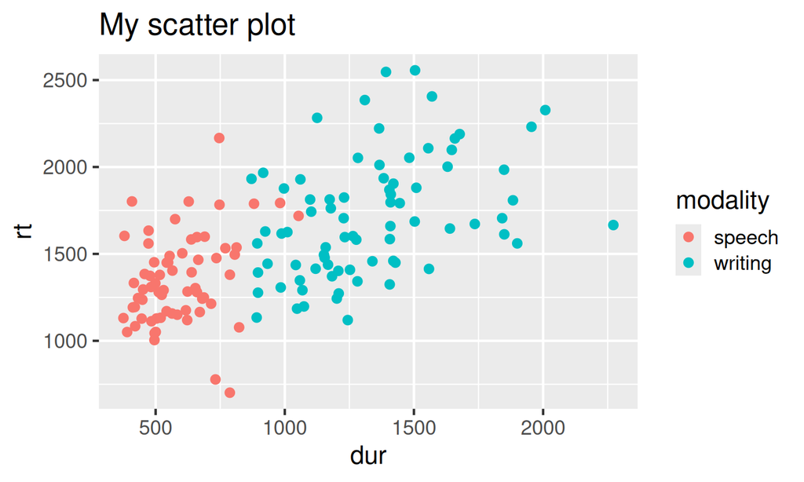

```r
ggplot(d_spellname, aes(y = rt, x = dur,
                          colour = modality)) +
  geom_point() +
  labs(title = "My scatter plot")
```

## Changing text: `labs`

- `title`
- `subtitle`
- `caption`
- `tag`
- `x`
- `y`
- `colour`, `shape`, `linetype`, `fill`

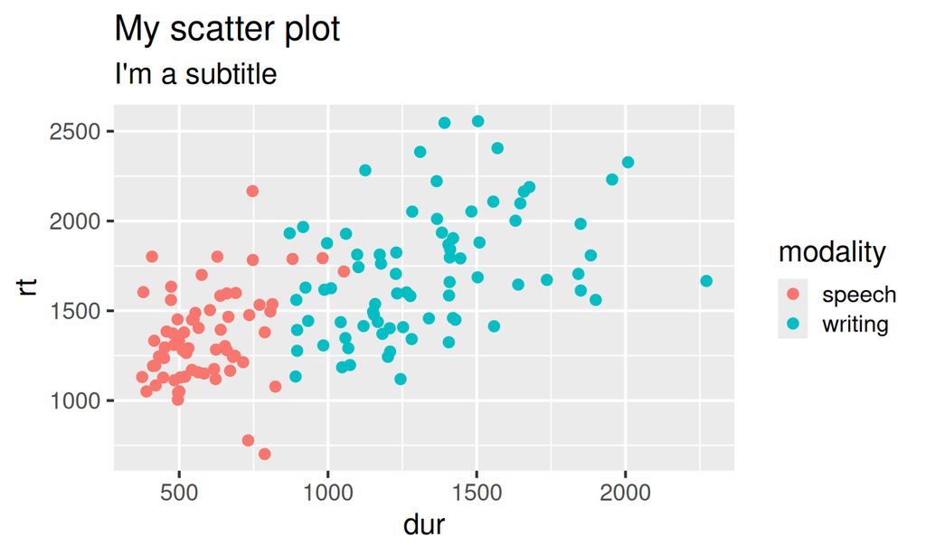

```r
ggplot(d_spellname, aes(y = rt, x = dur,
                          colour = modality)) +
  geom_point() +
  labs(title = "My scatter plot",
       subtitle = "I'm a subtitle")
```

## Changing text: `labs`

- `title`
- `subtitle`
- `caption`
- `tag`
- `x`
- `y`
- `colour`, `shape`, `linetype`, `fill`

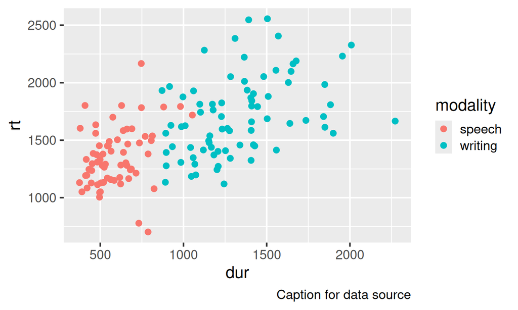

```r
ggplot(d_spellname, aes(y = rt, x = dur,
                          colour = modality)) +
  geom_point() +
  labs(caption = "Caption for data source")
```

## Changing text: `labs`

- `title`
- `subtitle`
- `caption`
- `tag`
- `x`
- `y`
- `colour`, `shape`, `linetype`, `fill`

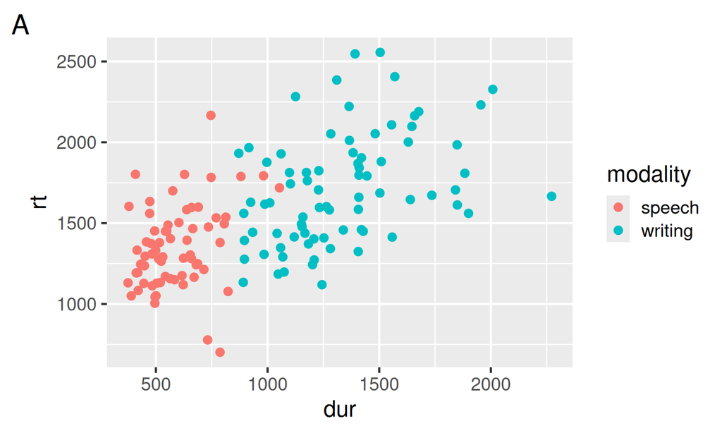

```r
ggplot(d_spellname, aes(y = rt, x = dur,
                          colour = modality)) +
  geom_point() +
  labs(tag = "A")
```

## Changing text: `labs`

- `title`
- `subtitle`
- `caption`
- `tag`
- `x`
- `y`
- `colour`, `shape`, `linetype`, `fill`

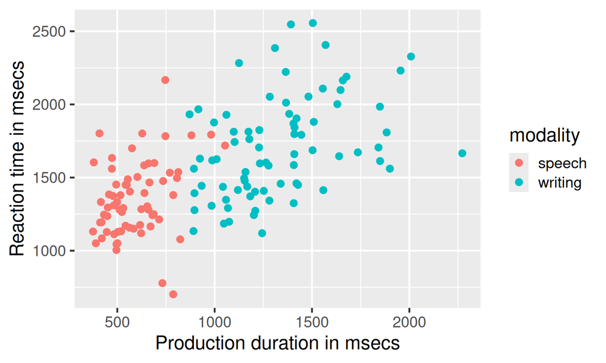

```r
ggplot(d_spellname, aes(y = rt, x = dur,
                          colour = modality)) +
  geom_point() +
  labs(x = "Production duration in msecs",
       y = "Reaction time in msecs")
```

## Changing text: `labs`

- `title`
- `subtitle`
- `caption`
- `tag`
- `x`
- `y`
- `colour`, `shape`, `linetype`, `fill`

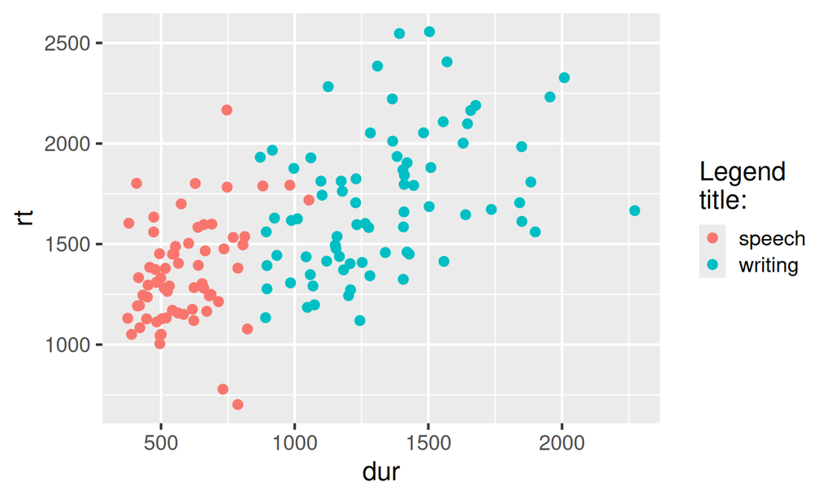

```r
ggplot(d_spellname, aes(y = rt, x = dur,
                          colour = modality)) +
  geom_point() +
  labs(colour = "Legend\ntitle:")
```

## Exercise 1: Changing text

Complete RMarkdown document `1_add_labs.Rmd`

## Changing text: legend keys

- `scale_colour_discrete`
- `scale_colour_continuous`
- `scale_colour_manual`
- or any other aesthetic instead of `colour`

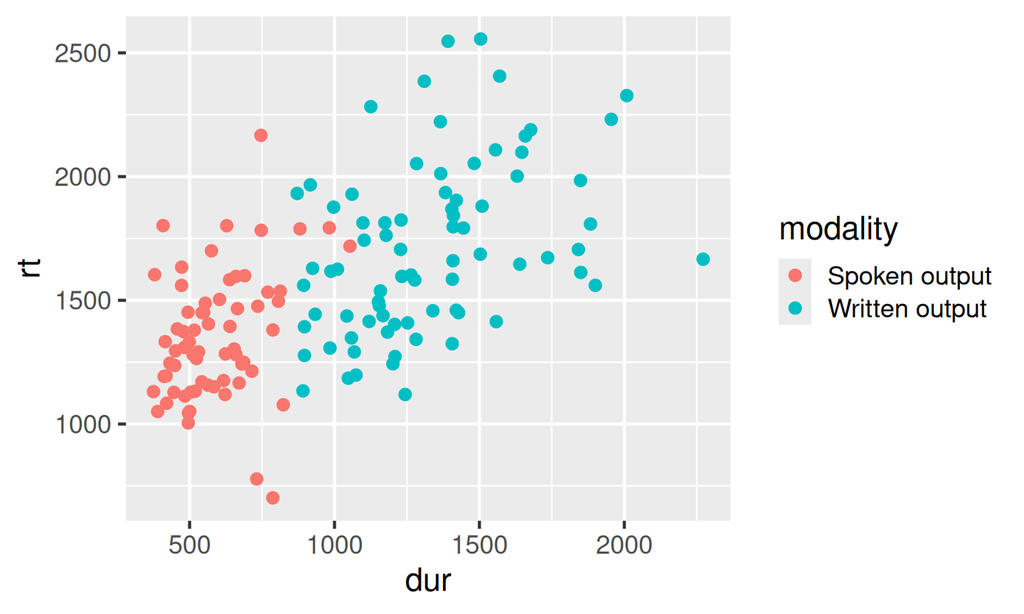

```r
ggplot(d_spellname, aes(y = rt, x = dur, colour = modality)) +
  geom_point() +
  scale_colour_discrete(
    labels = c("Spoken output", "Written output"))
```

## Changing text: legend keys

- Change colour values manually
- Colour names: [link](http://sape.inf.usi.ch/quick-reference/ggplot2/colour)
- `ggthemes`

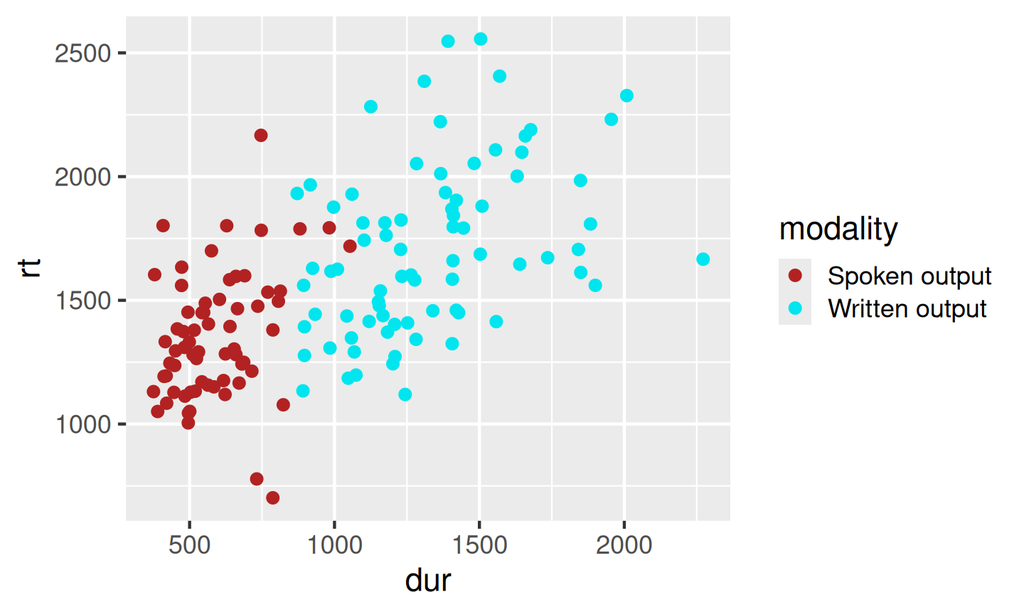

```r
ggplot(d_spellname, aes(y = rt, x = dur, colour = modality)) +
  geom_point() +
  scale_colour_manual(
    labels = c("Spoken output", "Written output"),
    values = c("firebrick", "turquoise2"))
```

## Changing text: legend keys

- Change colour values manually
- Colour names: [link](http://sape.inf.usi.ch/quick-reference/ggplot2/colour)
- `ggthemes`

```r
# RGB codes of "colorblind" function
mycolours <- c("#000000", "#E69F00", "#56B4E9", "#009E73",
               "#F0E442", "#0072B2", "#D55E00", "#CC79A7")
```

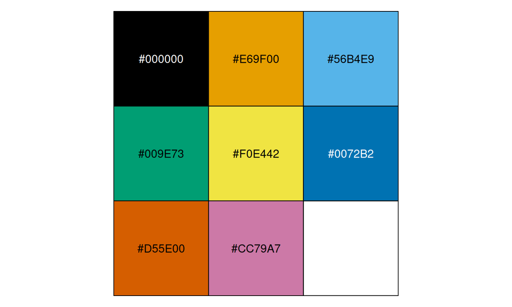

```r
# RGB codes of "colorblind" function
scales::show_col(colorblind_pal()(8))
```

## Changing text: legend keys

- Change colour values manually
- Colour names: [link](http://sape.inf.usi.ch/quick-reference/ggplot2/colour)
- `ggthemes`

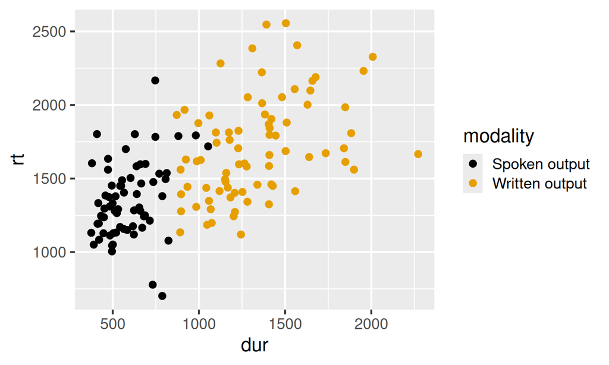

```r
ggplot(d_spellname, aes(y = rt, x = dur, colour = modality)) +
  geom_point() +
  scale_colour_manual(
    labels = c("Spoken output", "Written output"),
    values = mycolours[1:2])
```

## Changing text: legend keys

- Change colour values manually
- Colour names: [link](http://sape.inf.usi.ch/quick-reference/ggplot2/colour)
- `ggthemes`

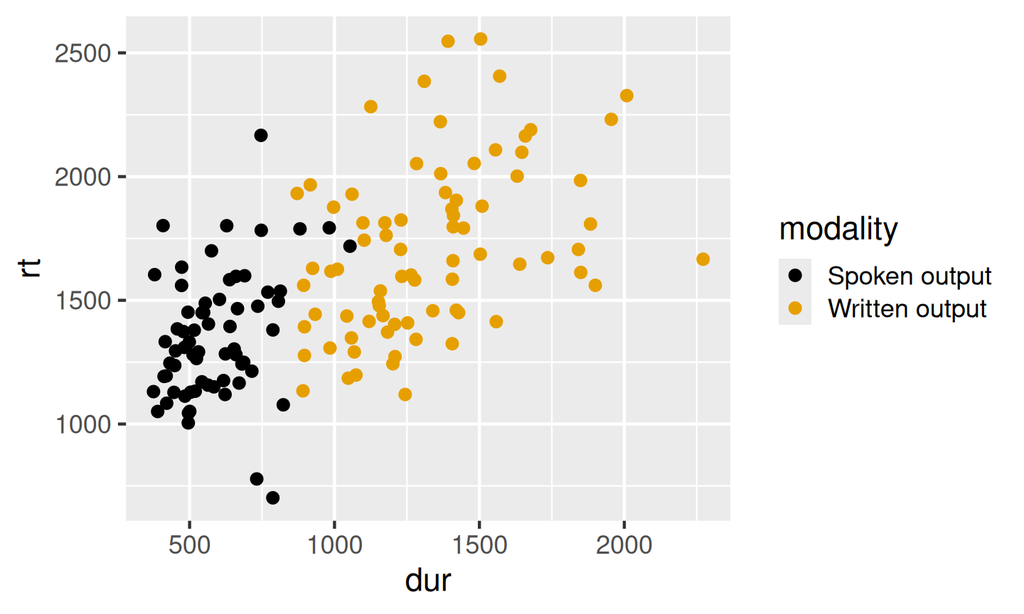

```r
ggplot(d_spellname, aes(y = rt, x = dur, colour = modality)) +
  geom_point() +
  scale_colour_colorblind(
    labels = c("Spoken output", "Written output"))
```

## Exercise 2: Customising colour aesthetics

Complete the RMarkdown `2_customising_aes.Rmd`

## Changing text: strips

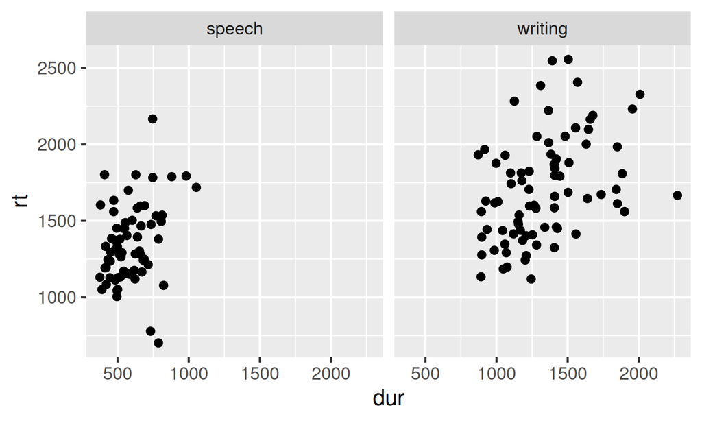

```r
ggplot(d_spellname, aes(y = rt, x = dur)) +
  geom_point() +
  facet_grid(~modality)
```

## Changing text: strips

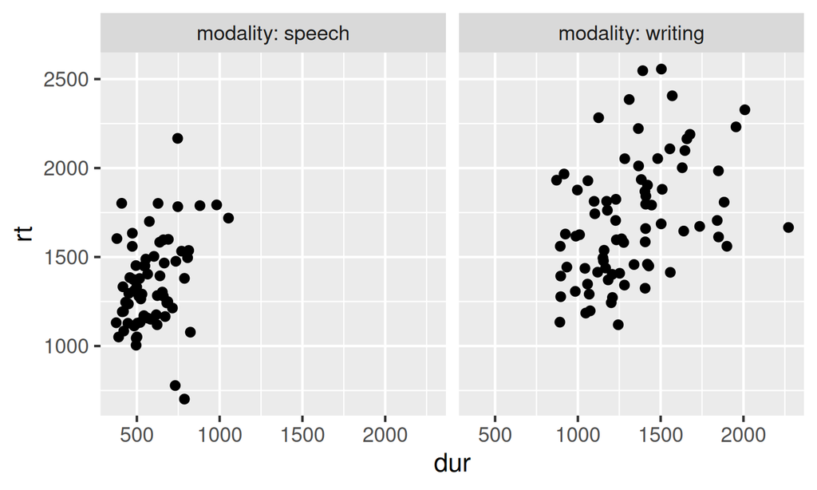

```r
ggplot(d_spellname, aes(y = rt, x = dur)) +
  geom_point() +
  facet_grid(~modality, labeller = label_both)
```

## Changing text: strips

```r
d_spellname <- mutate(d_spellname,
                    modality = recode(modality,
                    "speech" = "Spoken output",
                    "writing" = "Written output"))
```

[figure not shown]

## Changing text: strips

```r
d_spellname <- mutate(d_spellname,
                    modality = recode(modality,
                    "speech" = "Spoken output",
                    "writing" = "Written output"))
```

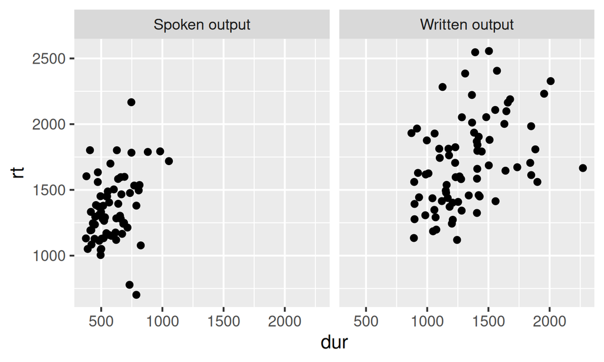

## Themes

- Specify appearance of non-data related ink
- Can be done manually using `themes()` or using wrapper functions
- All `ggplot2` wrappers:

```
[1] "theme_bw"       "theme_classic"  "theme_dark"     "theme_grey"
[5] "theme_light"    "theme_linedraw" "theme_minimal"  "theme_void"
```

- e.g. `ggthemes` package for more themes:

```
 [1] "theme_base"            "theme_calc"            "theme_clean"
 [4] "theme_economist"       "theme_economist_white" "theme_excel"
 [7] "theme_excel_new"       "theme_few"             "theme_fivethirtyeight"
[10] "theme_foundation"      "theme_gdocs"           "theme_hc"
[13] "theme_map"             "theme_pander"          "theme_par"
[16] "theme_solarized"       "theme_solarized_2"     "theme_solid"
[19] "theme_stata"           "theme_stata_base"      "theme_stata_colors"
[22] "theme_tufte"           "theme_wsj"
```

## Themes (`ggplot2` default)

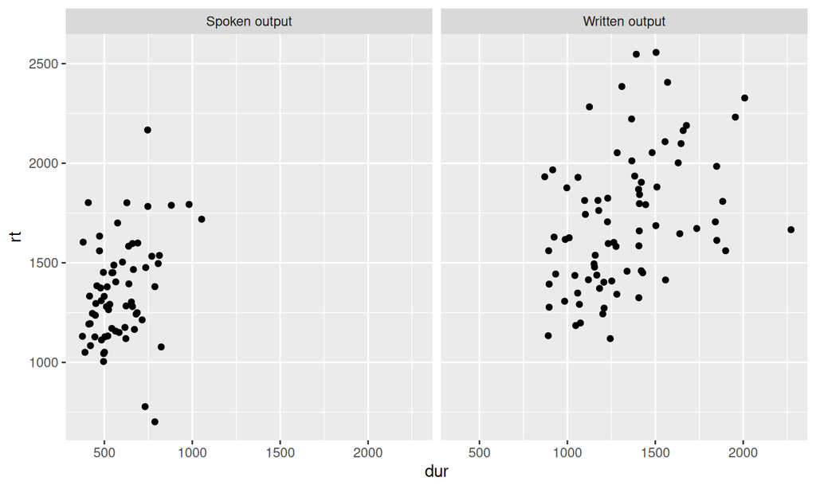

```r
ggplot(d_spellname, aes(y = rt, x = dur)) +
  geom_point() +
  facet_grid(~modality) +
  theme_grey(base_size = 11)
```

## Themes

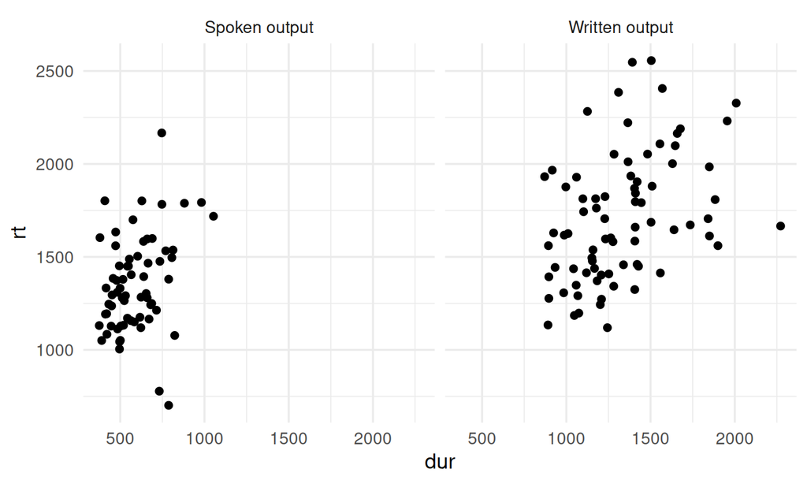

```r
ggplot(d_spellname, aes(y = rt, x = dur)) +
  geom_point() +
  facet_grid(~modality) +
  theme_minimal(base_size = 14)
```

## Themes

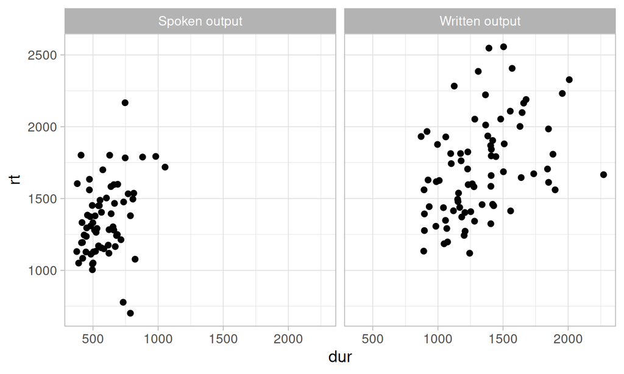

```r
ggplot(d_spellname, aes(y = rt, x = dur)) +
  geom_point() +
  facet_grid(~modality) +
  theme_light(base_size = 14)
```

## Themes

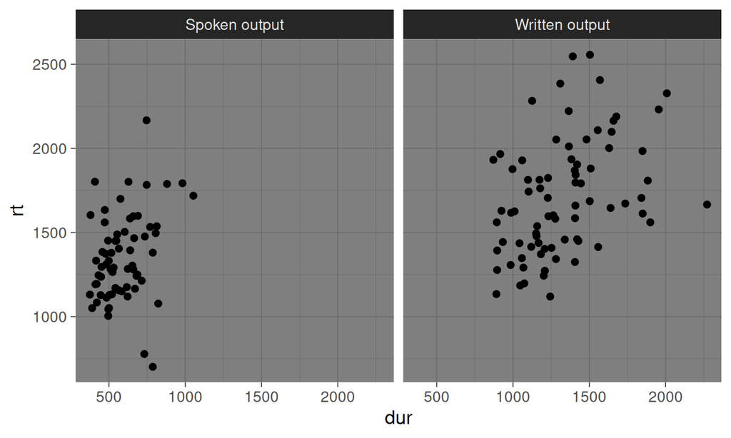

```r
ggplot(d_spellname, aes(y = rt, x = dur)) +
  geom_point() +
  facet_grid(~modality) +
  theme_dark(base_size = 14)
```

## Themes (`ggthemes`)

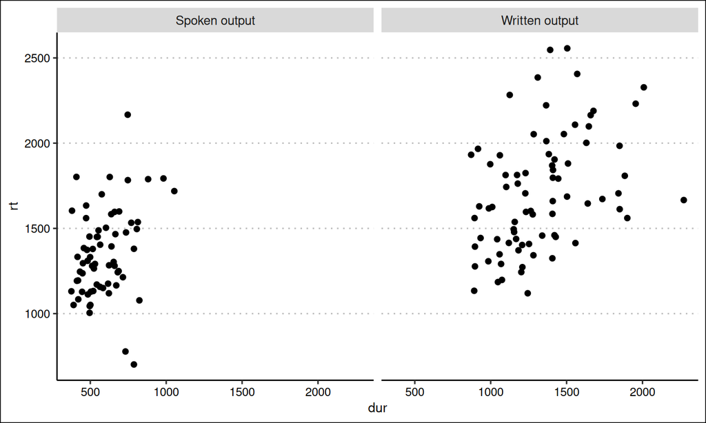

```r
ggplot(d_spellname, aes(y = rt, x = dur)) +
  geom_point() +
  facet_grid(~modality) +
  theme_clean()
```

## Themes

- `axis`
- `legend`
- `panel`
- `plot`
- `strip`

```r
ggplot(d_spellname, aes(y = rt, x = dur)) +
  geom_point() +
  theme()
```

[output not shown]

## Themes: `axis`

- `axis.text`
  - `axis.text.x`
  - `axis.text.y`
- `axis.title`
  - `axis.title.x`
  - `axis.title.y`

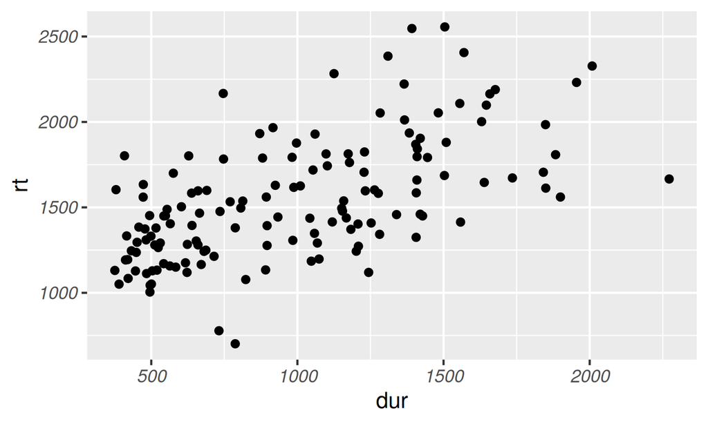

```r
ggplot(d_spellname, aes(y = rt, x = dur)) +
  geom_point() +
  theme(axis.text = element_text(face = "italic"))
```

## Themes: `axis`

- `axis.text`
  - `axis.text.x`
  - `axis.text.y`
- `axis.title`
  - `axis.title.x`
  - `axis.title.y`

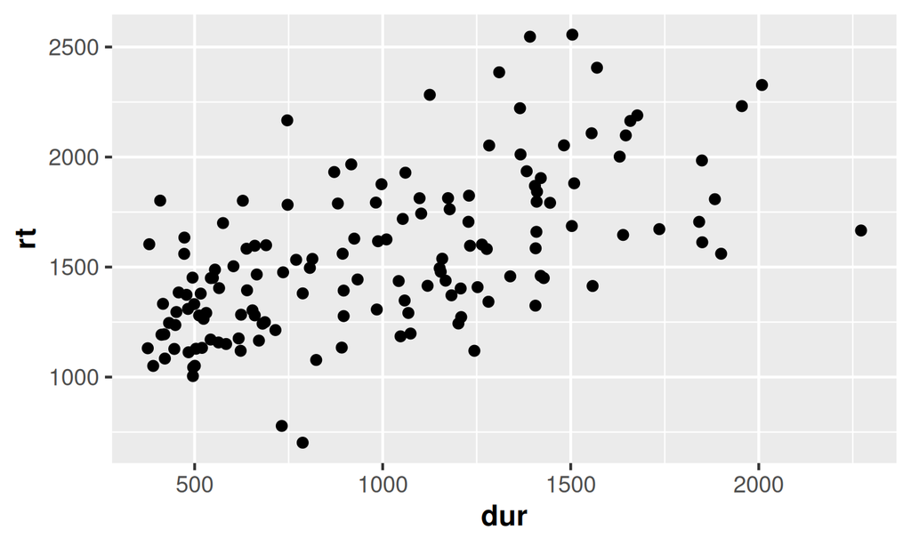

```r
ggplot(d_spellname, aes(y = rt, x = dur)) +
  geom_point() +
  theme(axis.title = element_text(face = "bold"))
```

## Themes: `axis`

- `axis.text`
  - `axis.text.x`
  - `axis.text.y`
- `axis.title`
  - `axis.title.x`
  - `axis.title.y`

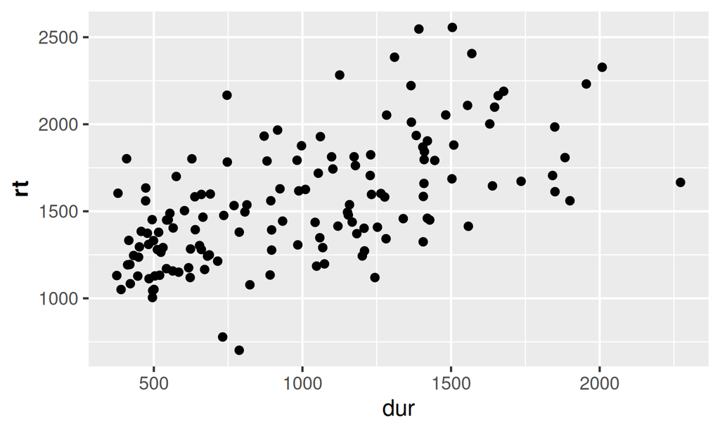

```r
ggplot(d_spellname, aes(y = rt, x = dur)) +
  geom_point() +
  theme(axis.title.y = element_text(face = "bold"))
```

## Themes: `legend`

- `legend.background`
- `legend.margin`
- `legend.spacing`
- `legend.key`
- `legend.text`
- `legend.title`
- `legend.position`
- `legend.orientation`
- `legend.justification`
- `legend.box`

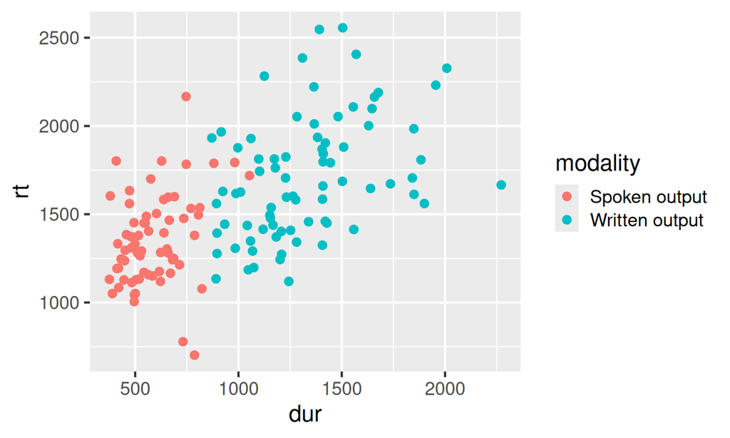

```r
ggplot(d_spellname, aes(y = rt, x = dur, colour = modality)) +
  geom_point() +
  theme()
```

## Themes: `legend`

- `legend.background`
- `legend.margin`
- `legend.spacing`
- `legend.key`
- `legend.text`
- `legend.title`
- `legend.position`
- `legend.orientation`
- `legend.justification`
- `legend.box`

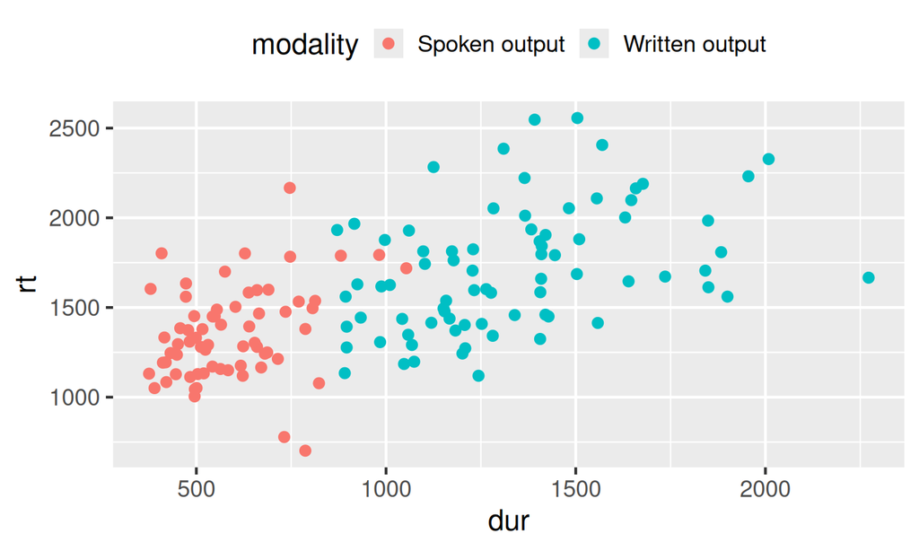

```r
ggplot(d_spellname, aes(y = rt, x = dur, colour = modality)) +
  geom_point() +
  theme(legend.position = "top")
```

## Themes: `legend`

- `legend.background`
- `legend.margin`
- `legend.spacing`
- `legend.key`
- `legend.text`
- `legend.title`
- `legend.position`
- `legend.orientation`
- `legend.justification`
- `legend.box`

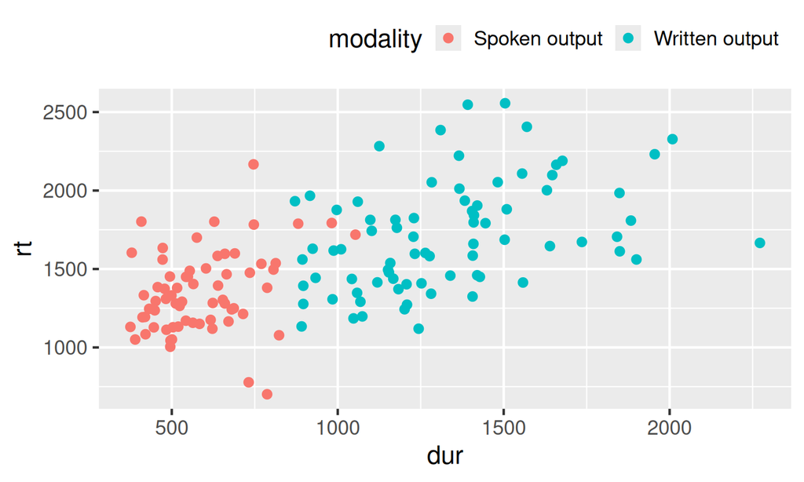

```r
ggplot(d_spellname, aes(y = rt, x = dur, colour = modality)) +
  geom_point() +
  theme(legend.position = "top",
        legend.justification = "right")
```

## Themes: `legend`

- `legend.background`
- `legend.margin`
- `legend.spacing`
- `legend.key`
- `legend.text`
- `legend.title`
- `legend.position`
- `legend.orientation`
- `legend.justification`
- `legend.box`

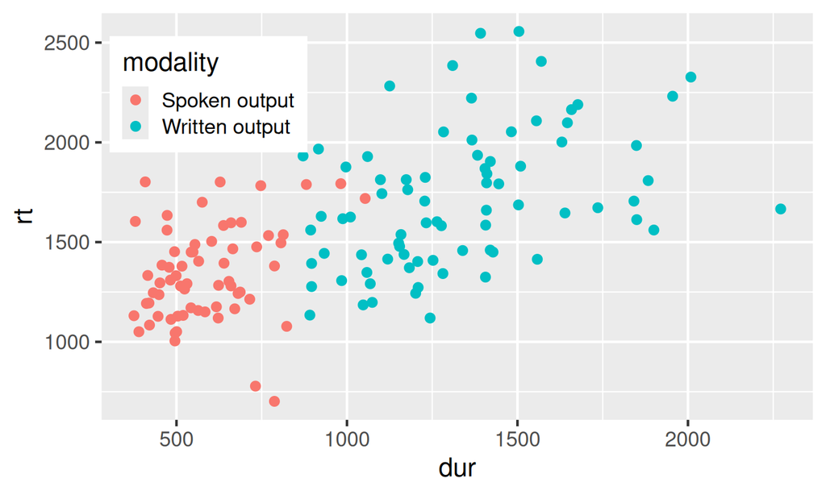

```r
ggplot(d_spellname, aes(y = rt, x = dur, colour = modality))+
  geom_point() +
  theme(legend.position = c(.15,.8))
```

## Themes: `panel`

- `panel.background`
- `panel.border`
- `panel.spacing`
- `panel.grid`
  - `panel.grid.major`
  - `panel.grid.minor`

```r
ggplot(d_spellname, aes(y = rt, x = dur)) +
  geom_point() +
  theme()
```

[output not shown]

## Themes: `panel`

- `panel.background`
- `panel.border`
- `panel.spacing`
- `panel.grid`
  - `panel.grid.major`
  - `panel.grid.minor`

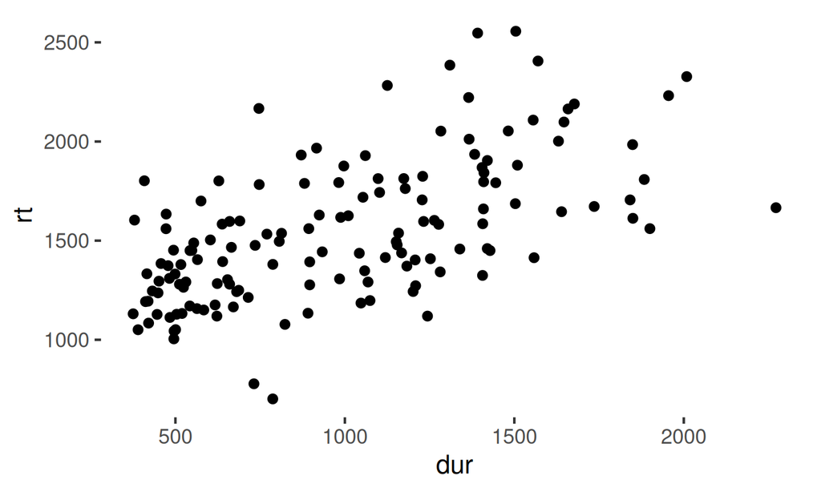

```r
ggplot(d_spellname, aes(y = rt, x = dur)) +
  geom_point() +
  theme(panel.background = element_blank())
```

## Themes: `plot`

- `plot.background`
- `plot.margin`
- `plot.title`
- `plot.subtitle`
- `plot.caption`
- `plot.tag`

```r
ggplot(d_spellname, aes(y = rt, x = dur)) +
  geom_point() +
  theme()
```

[output not shown]

## Themes: `plot`

- `plot.background`
- `plot.margin`
- `plot.title`
- `plot.subtitle`
- `plot.caption`
- `plot.tag`

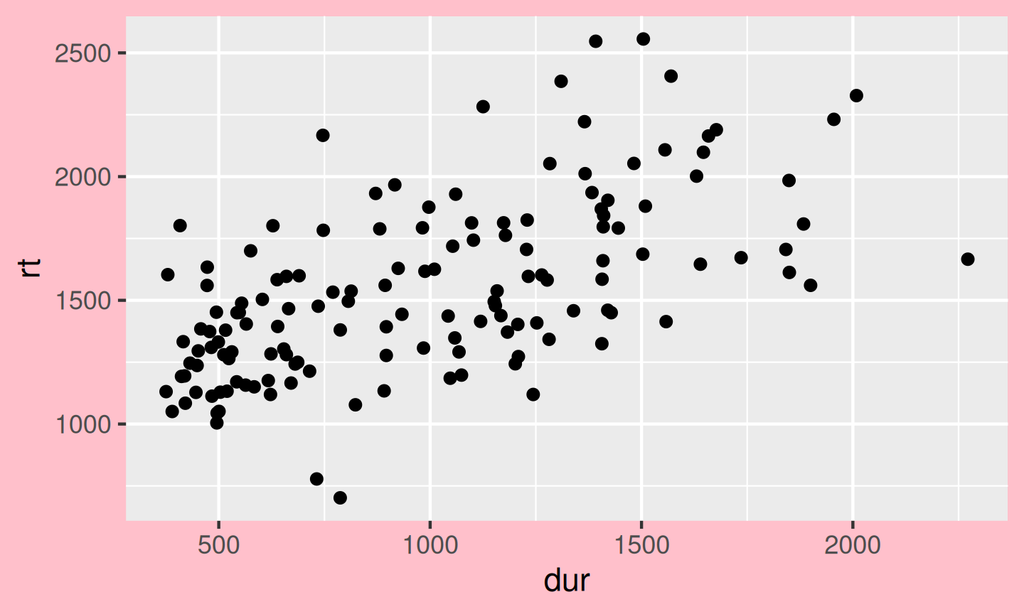

```r
ggplot(d_spellname, aes(y = rt, x = dur)) +
  geom_point() +
  theme(plot.background = element_rect(fill = "pink"))
```

## Themes: `plot`

- `plot.background`
- `plot.margin`
- `plot.title`
- `plot.subtitle`
- `plot.caption`
- `plot.tag`

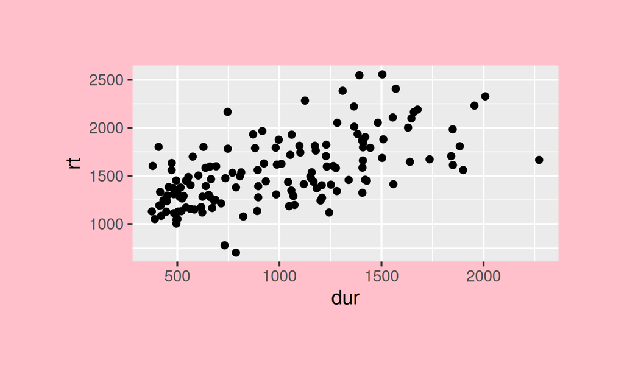

```r
ggplot(d_spellname, aes(y = rt, x = dur)) +
  geom_point() +
  theme(plot.background = element_rect(fill = "pink"),
        plot.margin = unit(c(2,2,2,2), "cm"))
```